# ISC (095340) 기업 분석 보고서

Alpha Hunter Hidden Gem Week 20 — 반도체 테스트 소켓 글로벌 1위, SEPA 7/7 통과

Author

Alpha Hunter × Chimera AI

Published

May 14, 2026

# 기업 개요

| 항목 | 내용 |
| --- | --- |
| **종목명** | ISC (아이에스시, 095340, KOSDAQ) |
| **업종** | 반도체 장비 / 테스트 소켓 |
| **핵심 사업** | 실리콘러버 테스트 소켓 (반도체 후공정 검사용) |
| **시총** | 5.1조원 |
| **현재가** | 253,500원 |
| **PER (Fwd)** | 약 25x |
| **영업이익률** | 34.6% (Q1 2026) |
| **52주 범위** | ~78,000원 — ~277,000원 |
| **SEPA 점수** | **7/7 통과** |

> **핵심 투자 포인트**: 글로벌 실리콘러버 테스트 소켓 시장 점유율 90%. Q1 매출 683억(+115.5% YoY), 영업이익 236억(+237.8% YoY). AI 가속기(GPU/ASIC) + HBM 테스트 수요 폭발. SEPA 7개 조건 모두 충족.

# 1 SEPA 트렌드 템플릿 분석 (Mark Minervini)

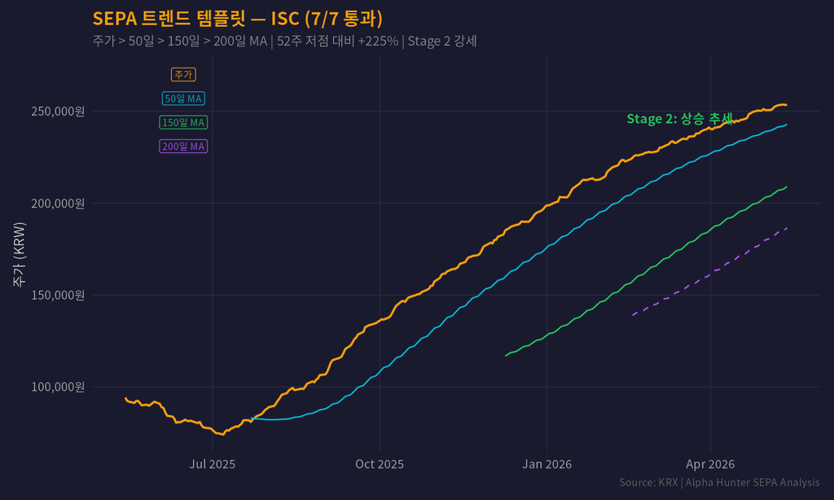

Figure 1: SEPA 트렌드 템플릿 — ISC 7/7 통과, Stage 2 상승 추세 확인

### 1.0.1 SEPA 7개 조건 체크리스트

[output not shown]

# 2 왜 지금 ISC인가?

## 2.1 글로벌 실리콘러버 테스트 소켓 시장 점유율 90%

ISC는 반도체 후공정 테스트에 사용되는 **실리콘러버 소켓**의 글로벌 독점 기업이다:

- **시장 점유율 90%**: 실리콘러버 소켓 세계 1위
- **고객**: SK하이닉스, 삼성전자, 마이크론, NVIDIA, AMD, Google, Apple 등
- **핵심 역량**: 초미세 피치(0.4mm 이하) 대응, HBM 적층 메모리 테스트 가능

## 2.2 AI 가속기 + HBM = 테스트 수요 폭발

AI 반도체 시대에 테스트 소켓 수요가 구조적으로 증가하는 이유:

1. **GPU/ASIC**: NVIDIA H100/B200/GB200, Google TPU, AMD MI → 칩 복잡도 증가 → 테스트 시간 증가
2. **HBM**: 12-16단 적층 → 기존 DRAM 대비 테스트 횟수 3-5배
3. **시스템레벨 테스트**: AI칩 + HBM 결합 테스트 → 새로운 소켓 수요 창출
4. **HBM4**: 2026년 양산 시작 → 테스트 강도 추가 증가

## 2.3 SK하이닉스 + 삼성전자 = 쌍두마차

- **SK하이닉스**: HBM 글로벌 1위 (점유율 54-55%), ISC의 최대 고객
- **삼성전자**: HBM 점유율 28-29%로 추격. 2027년까지 SK하이닉스와 동등 수준 목표
- **마이크론**: 3위 (17-18%). ISC 납품 확대 중

3사 모두 HBM 증산에 사활을 걸고 있어, ISC의 수혜는 구조적이다.

# 3 실적 분석

## 3.1 Q1 2026 — 매출/이익 동반 폭증

| 지표 | Q1 2026 | Q1 2025 | YoY |
| --- | --- | --- | --- |
| **매출** | 683억원 | 317억원 | **+115.5%** |
| **영업이익** | 236억원 | 70억원 | **+237.8%** |
| **영업이익률** | 34.6% | 22.1% | +12.5%p |
| **데이터센터 매출** | 542억원 | 169억원 | **+220.7%** |
| **DC 비중** | 79.4% | 53.3% | +26.1%p |

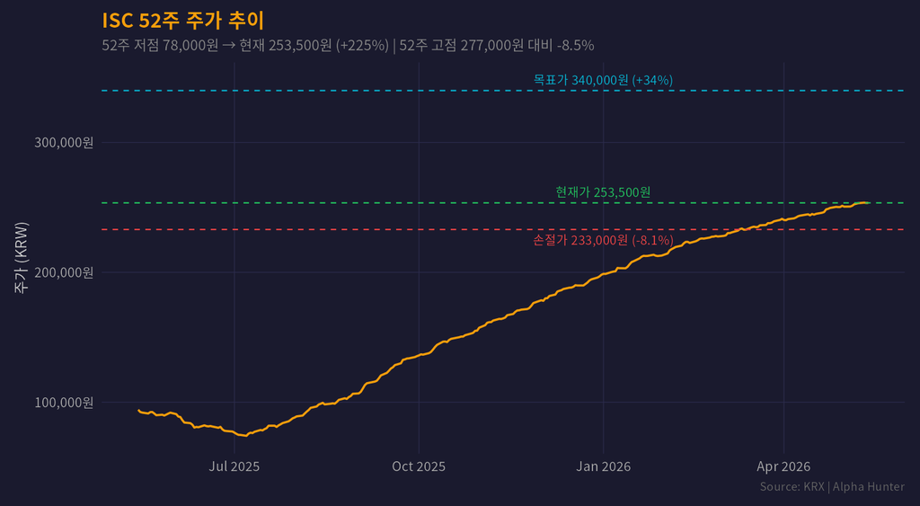

Figure 2: ISC 52주 주가 추이 — 52주 저점 78,000원 → 현재 253,500원 (+225%)

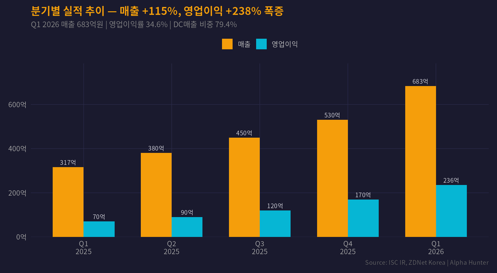

Figure 3: 분기별 매출 및 영업이익 추이 — AI 수혜로 폭발 성장

## 3.2 2026 연간 전망

# 4 밸류에이션 비교

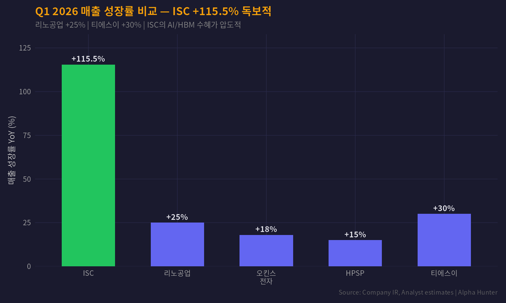

Figure 4: 동종업종 매출 성장률 비교 — ISC +115% 압도적

### 4.0.1 ISC vs 경쟁사 비교

| 기업 | 시총 | 매출 성장 | OPM | 핵심 제품 |
| --- | --- | --- | --- | --- |
| **ISC** | 5.1조 | +115.5% | 34.6% | 실리콘러버 소켓 (M/S 90%) |
| 리노공업 | 5.5조 | +25% | 30.0% | 포고핀 소켓 |
| 오킨스전자 | 0.3조 | +18% | 12.0% | 테스트 소켓 |
| HPSP | 4.2조 | +15% | 52.1% | HPA 어닐링 장비 |
| 티에스이 | 1.0조 | +30% | 20.0% | 테스트 인터페이스 |

# 5 워런 버핏 해자 분석

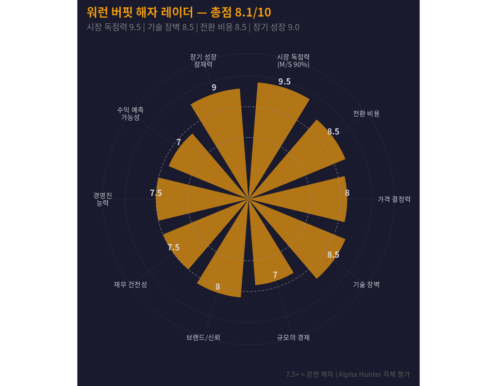

Figure 5: 워런 버핏 해자(Moat) 분석 — 시장 독점 + 전환 비용

### 5.0.1 해자 분석 요약 — 총점 8.1/10

- **시장 독점력 (9.5)**: 글로벌 실리콘러버 테스트 소켓 M/S 90%. 사실상 독점
- **기술 장벽 (8.5)**: 초미세 피치 실리콘러버 가공 기술. 20년+ 축적된 제조 노하우. 경쟁사 진입 극히 어려움
- **전환 비용 (8.5)**: 소켓 교체 시 테스트 레시피 재설정 + 퀄리파이 3-6개월. 고객 락인 강력
- **장기 성장 (9.0)**: AI 가속기 + HBM + 차세대 메모리 → 테스트 횟수/복잡도 구조적 증가

# 6 피터 린치 스토리 점수

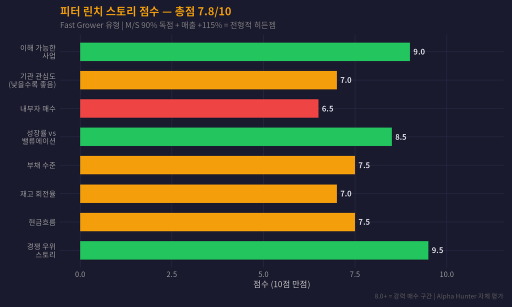

Figure 6: 피터 린치 스토리 점수 — 독점 + 고속 성장 히든젬

### 6.0.1 피터 린치 분류 — “Fast Grower”

1. **경쟁 우위 스토리 (9.5)**: “반도체 칩이 만들어질 때마다 ISC 소켓이 필요하다.” M/S 90% 독점
2. **이해 가능한 사업 (9.0)**: 반도체 테스트용 소켓. 단순명쾌한 비즈니스 모델
3. **성장률 vs 밸류에이션 (8.5)**: 매출 +115.5%, 영업이익 +238%. 현재 PER ~25x
4. **현금흐름 (7.5)**: 높은 영업이익률(34.6%) + 베트남 공장 500억 투자로 CAPA 확대 중

# 7 리스크 분석

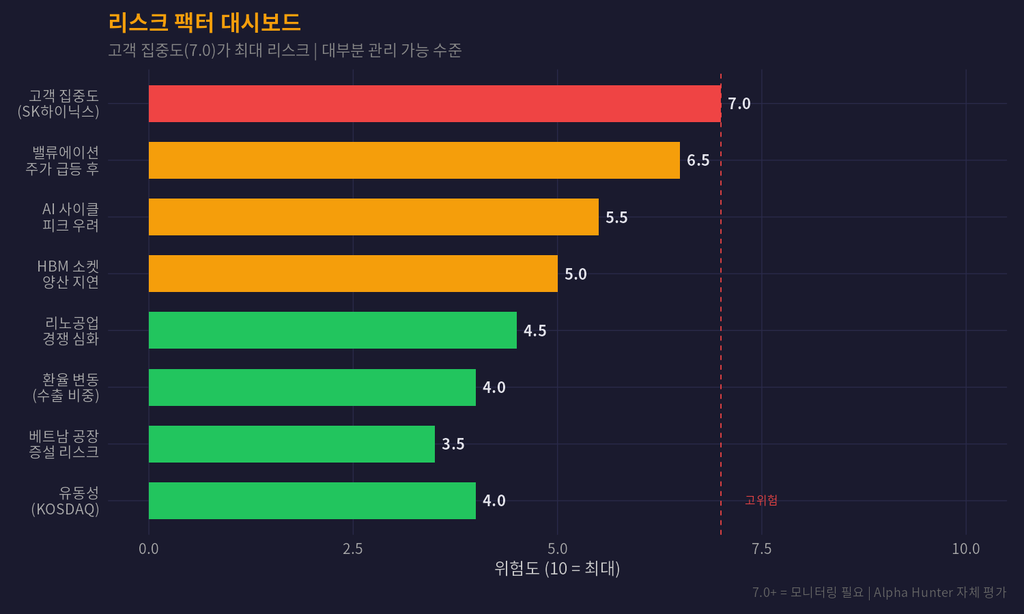

Figure 7: 리스크 팩터 대시보드 — 고객 집중 + 밸류에이션이 주요 리스크

# 8 HBM 시장과 ISC의 포지션

## 8.1 HBM 시장 전망

| 연도 | SK하이닉스 | 삼성전자 | 마이크론 |
| --- | --- | --- | --- |
| **2026** | 54-55% | 28-29% | 17-18% |
| **2027** | ~40% | ~40% | ~20% |

SK하이닉스 + 삼성전자 + 마이크론 3사 모두 ISC의 고객. HBM4 16단 적층 → 테스트 복잡도 추가 증가 → ISC 수혜 극대화.

## 8.2 ISC의 HBM 전략

- **HBM 테스트 소켓**: 2026년 1-2분기 양산 착수
- **시스템레벨 테스트 소켓**: AI 가속기(GPU+HBM) 결합 테스트용
- **빅테크 AI칩 점유율 50% 목표**: NVIDIA, Google, AMD ASIC 테스트 소켓
- **베트남 공장 500억 투자**: 공정자동화 + 증설로 납기 대응력 강화

# 9 투자 시나리오

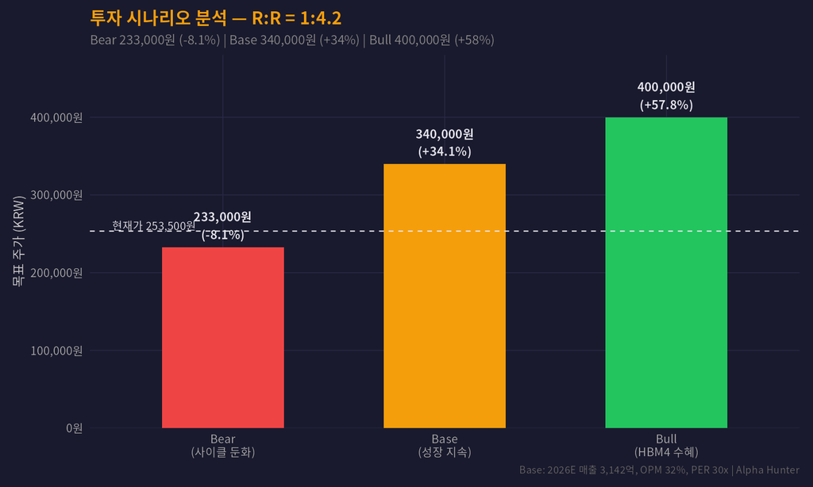

Figure 8: 매수/목표/손절 시나리오 — R:R = 1:4.2

### 9.0.1 밸류에이션 근거

**Bull Case (400,000원, +58%)**:

- HBM4 테스트 소켓 양산 성공 + 빅테크 ASIC 수주 확대
- 2026E 매출 3,500억원+, OPM 35%
- PER 32x 적용

**Bear Case (233,000원, -8.1%)**:

- AI 투자 사이클 둔화, HBM 수요 감소
- 매출 성장 +20% 수준으로 감속

**Risk:Reward = 1:4.2** (손실 20,500원 vs 이익 86,500원 base)

# 10 매수 전략

| 항목 | 수치 |
| --- | --- |
| **매수가** | 253,500원 (현재가) |
| **1차 목표** | 340,000원 (+34%) |
| **2차 목표** | 400,000원 (+58%) |
| **손절가** | 233,000원 (-8.1%) |
| **R:R** | 1:4.2 |
| **투자 기간** | 6~12개월 |

## 10.1 카탈리스트 일정

- **Q2 2026 실적발표 (7월)**: DC매출 비중 80%+ 지속 확인
- **HBM 테스트 소켓 양산**: 2026 상반기 본격 양산 착수
- **HBM4 양산 (하반기)**: SK하이닉스/삼성 동시 → 테스트 수요 급증
- **빅테크 ASIC 수주**: Google TPU, Amazon Trainium 등
- **베트남 공장 증설 완료**: CAPA 확대 → 매출 성장 가속

# 11 결론

> **ISC는 “AI 반도체 테스트의 독점 게이트키퍼”다.**

**면책 문구**

이 프로젝트는 가상 투자 시뮬레이션 목적으로 작성되었습니다. 실제 투자 권유가 아니며, 모든 투자 결정은 개인의 판단과 책임 하에 이루어져야 합니다.